# Week2lab

Ismail

9/1/2020

## Executive summary

It is a dream for every person to buy their own house so that they can live in peace without having to worry about having to vacate. Besides it is always a good and safe investment. In this assignment, we will investigate the different factors which can influence house prices.

## Introduction

In 2019, Melbourne was declared as the most livable city on earth. This well deserved title can be accredited to its pleasant weather, beautiful architecture and safety rating. The city is a prime attraction for migration and has potential for great returns on real estate investment.

## 1.1 Load data

We will load the melbourne dataset which contains detail of houses sold in years 2016 - 2018.

```r
melbdata <- read.csv("Melbourne_housing_FULL.csv", header = TRUE)
head(melbdata)
```

```
##       Suburb            Address Rooms Type   Price Method SellerG      Date
## 1 Abbotsford      68 Studley St     2    h      NA     SS  Jellis 3/09/2016
## 2 Abbotsford       85 Turner St     2    h 1480000      S  Biggin 3/12/2016
## 3 Abbotsford    25 Bloomburg St     2    h 1035000      S  Biggin 4/02/2016
## 4 Abbotsford 18/659 Victoria St     3    u      NA     VB  Rounds 4/02/2016
## 5 Abbotsford       5 Charles St     3    h 1465000     SP  Biggin 4/03/2017
## 6 Abbotsford   40 Federation La     3    h  850000     PI  Biggin 4/03/2017
##   Distance Postcode Bedroom2 Bathroom Car Landsize BuildingArea YearBuilt
## 1      2.5     3067        2        1   1      126           NA        NA
## 2      2.5     3067        2        1   1      202           NA        NA
## 3      2.5     3067        2        1   0      156           79      1900
## 4      2.5     3067        3        2   1        0           NA        NA
## 5      2.5     3067        3        2   0      134          150      1900
## 6      2.5     3067        3        2   1       94           NA        NA
##          CouncilArea Lattitude Longtitude            Regionname Propertycount
## 1 Yarra City Council  -37.8014   144.9958 Northern Metropolitan          4019
## 2 Yarra City Council  -37.7996   144.9984 Northern Metropolitan          4019
## 3 Yarra City Council  -37.8079   144.9934 Northern Metropolitan          4019
## 4 Yarra City Council  -37.8114   145.0116 Northern Metropolitan          4019
## 5 Yarra City Council  -37.8093   144.9944 Northern Metropolitan          4019
## 6 Yarra City Council  -37.7969   144.9969 Northern Metropolitan          4019
```

## 1.2 Initial analysis

For our analysis we will be looking at Brunswick, Craigieburn and Hawthorn suburbs only. We will perform initial data analysis to gain insights. We will also print out statistical summaries of each suburb.

```r
suburbs <- subset(melbdata, Suburb == "Hawthorn" | Suburb == "Brunswick" | Suburb == "Craigieburn")
dim(suburbs)
```

```
## [1] 1127   21
```

```r
colnames(suburbs)
```

```
##  [1] "Suburb"        "Address"       "Rooms"         "Type"
##  [5] "Price"         "Method"        "SellerG"       "Date"
##  [9] "Distance"      "Postcode"      "Bedroom2"      "Bathroom"
## [13] "Car"           "Landsize"      "BuildingArea"  "YearBuilt"
## [17] "CouncilArea"   "Lattitude"     "Longtitude"    "Regionname"
## [21] "Propertycount"
```

```r
nrow(suburbs)
```

```
## [1] 1127
```

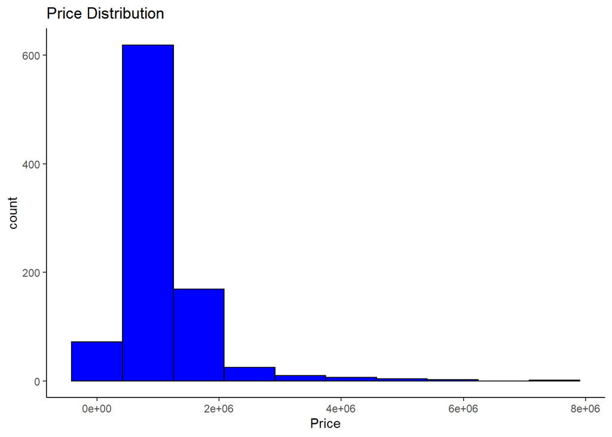

```r
ggplot(suburbs, aes(Price)) + geom_histogram(fill = "blue", color = "black",
    bins = 10) + theme_classic() + labs(title = "Price Distribution")
```

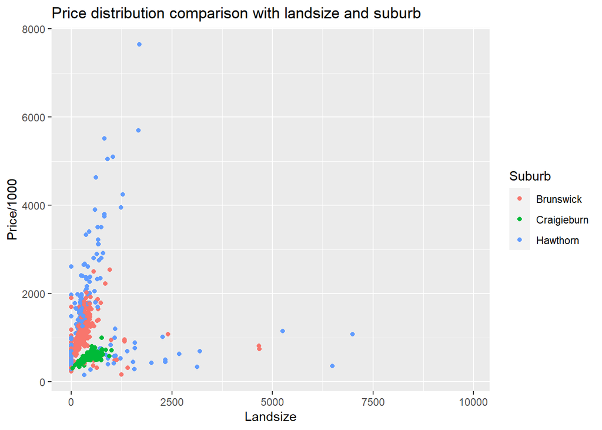

```r
ggplot(suburbs, aes(Landsize, Price/1000, color = Suburb)) + geom_point() + labs(title = "Price distribution comparison with landsize and suburb")
```

```r
summary(suburbs$Price[which(suburbs$Suburb == "Hawthorn")])
```

```
##    Min. 1st Qu.  Median    Mean 3rd Qu.    Max.    NA's
##  160000  517750  750500 1238074 1657500 7650000     118
```

```r
summary(suburbs$Price[which(suburbs$Suburb == "Craigieburn")])
```

```
##    Min. 1st Qu.  Median    Mean 3rd Qu.    Max.    NA's
##  310000  502500  562500  566174  627500 1000000      44
```

```r
summary(suburbs$Price[which(suburbs$Suburb == "Brunswick")])
```

```
##    Min. 1st Qu.  Median    Mean 3rd Qu.    Max.    NA's
##  170000  681000  950000  977989 1252500 2545000      57
```

It can be seen that the price distribution is heavily skewed towards the right side. Also it can be seen that the landsize has little effect on Price however, a clear distinction can be seen among prices in different suburbs. Craigieburn appears to the cheapest suburb to live in followed by Brunswick and Hawthorn. Some of the data point have a landsize of zero which does not make sense.

## 1.3 Finding association 1

To observe the relationship between building area and price, we will construct a simple linear regression model.

```r
lmfit <- lm(Price ~ BuildingArea, data = suburbs)
lmfit
```

```
##
## Call:
## lm(formula = Price ~ BuildingArea, data = suburbs)
##
## Coefficients:
##  (Intercept)  BuildingArea
##       518192          3801
```

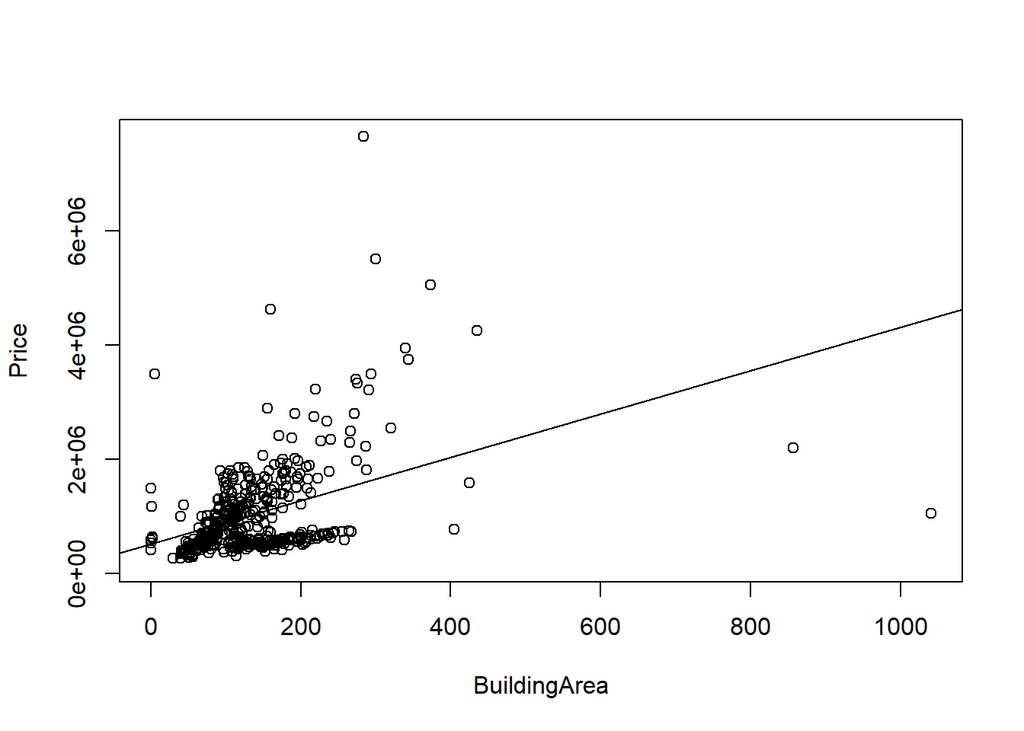

```r
plot(suburbs$BuildingArea, suburbs$Price, xlab = 'BuildingArea', ylab = 'Price')
abline(lmfit)
```

The above model has an R square value of 0.3527 which indicates a poor fitted model. This was expected from initial data analysis which indicated price to be more dependent on suburb rather than landsize.

# 1.4a Finding association 2

Constructing a multi variable regression model by adding suburb variable to the predictor and experimenting with other variables as well

```r
lmfit2 <- lm(Price ~ Suburb + BuildingArea, data = suburbs)
summary(lmfit2)
```

```
##
## Call:
## lm(formula = Price ~ Suburb + BuildingArea, data = suburbs)
##
## Residuals:
##      Min       1Q   Median       3Q      Max
## -4074050  -248461   -26674   166018  5479862
##
## Coefficients:
##                    Estimate Std. Error t value Pr(>|t|)
## (Intercept)        509756.7    62451.0   8.163 3.99e-15 ***
## SuburbCraigieburn -660277.3    72911.5  -9.056  < 2e-16 ***
## SuburbHawthorn     400715.9    72543.5   5.524 5.87e-08 ***
## BuildingArea         4435.4      346.9  12.786  < 2e-16 ***
## ---
## Signif. codes:  0 '***' 0.001 '**' 0.01 '*' 0.05 '.' 0.1 ' ' 1
##
## Residual standard error: 609900 on 414 degrees of freedom
##   (709 observations deleted due to missingness)
## Multiple R-squared:  0.425,  Adjusted R-squared:  0.4208
## F-statistic:   102 on 3 and 414 DF,  p-value: < 2.2e-16
```

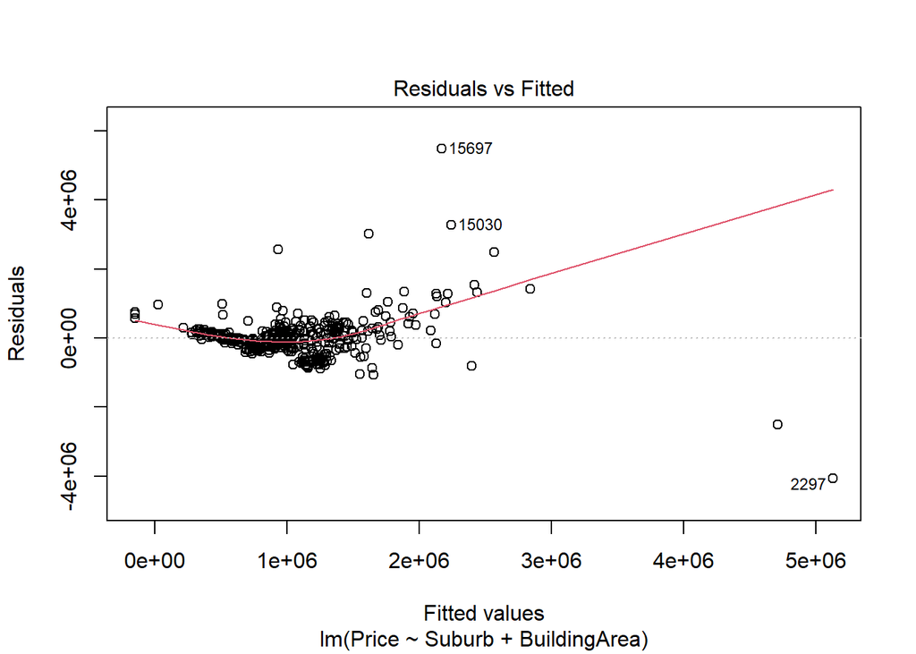

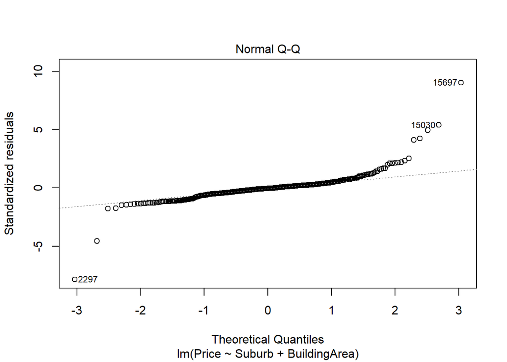

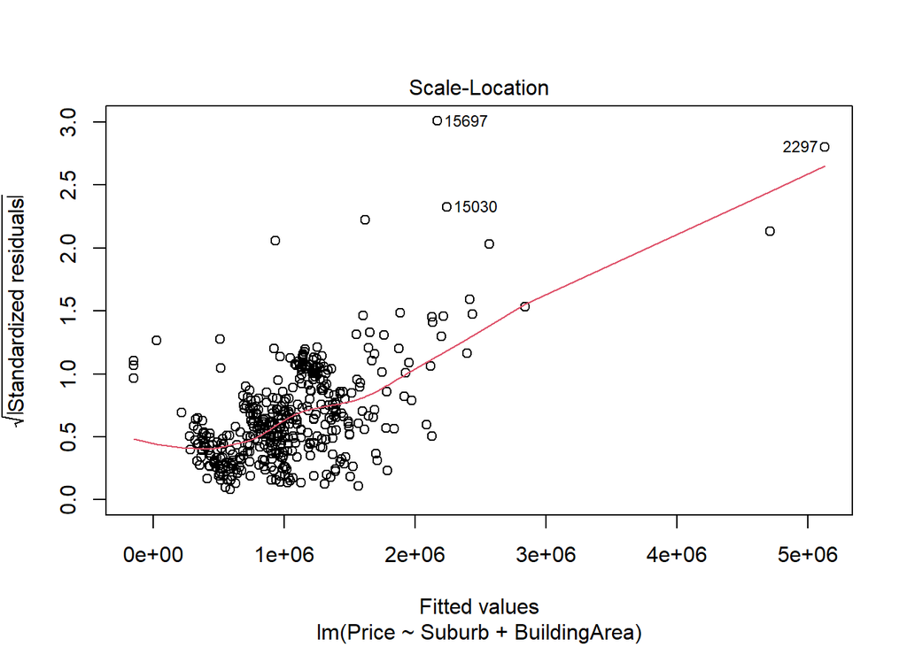

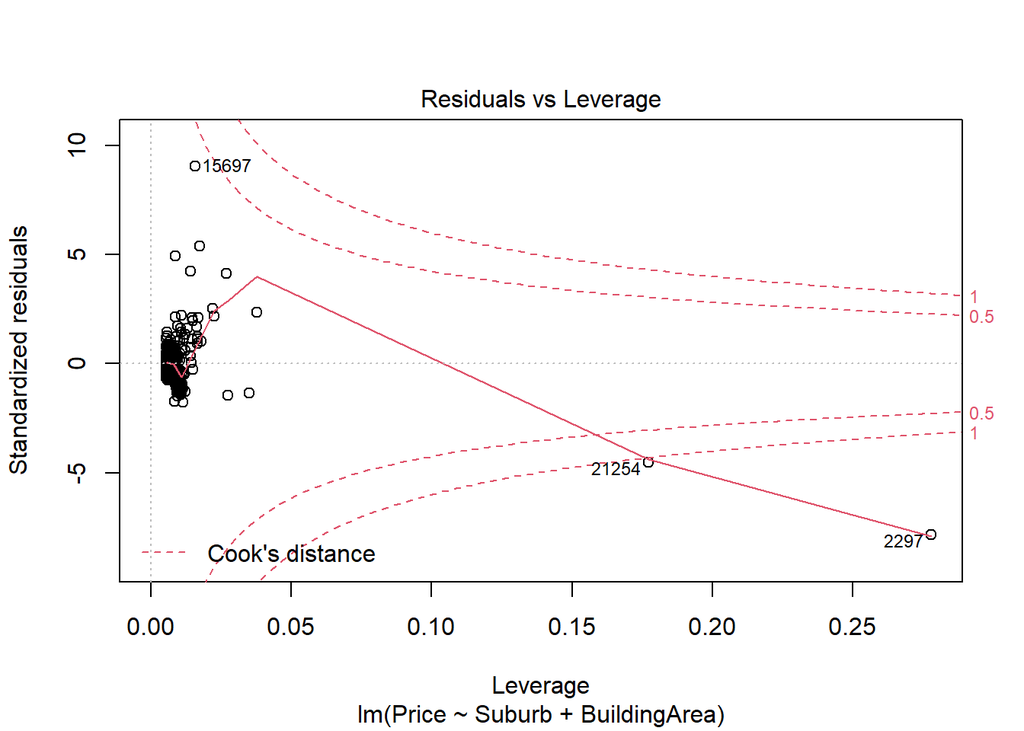

```r
plot(lmfit2)
```

As can be seen the intercepts for the model are 509756, -150521 and 910471 for brunswick, craigieburn and hawthorn respectively which indicates average price of hawthorn is the highest and craigieburn is the lowest and the gradient is 4435. This indicates that for a particular suburb for every m2 of area, the price goes up by $4435. R squared value is 0.425 which indicates a better fitting than a univariate model with only the building area as the predictor.

# 1.4b

we will assess whether adding the number of car spaces improves our model or not using two different models

```r
lmfit3 <- lm(Price ~ Suburb + BuildingArea + Car, data = suburbs)
summary(lmfit3)
```

```
##
## Call:
## lm(formula = Price ~ Suburb + BuildingArea + Car, data = suburbs)
##
## Residuals:
##      Min       1Q   Median       3Q      Max
## -3417281  -273352   -59191   252474  5001704
##
## Coefficients:
##                    Estimate Std. Error t value Pr(>|t|)
## (Intercept)        333560.7    67011.4   4.978 9.56e-07 ***
## SuburbCraigieburn -781107.7    73776.4 -10.588  < 2e-16 ***
## SuburbHawthorn     363436.8    71139.5   5.109 5.02e-07 ***
## BuildingArea         3761.7      351.3  10.708  < 2e-16 ***
## Car                220740.5    34616.8   6.377 4.98e-10 ***
## ---
## Signif. codes:  0 '***' 0.001 '**' 0.01 '*' 0.05 '.' 0.1 ' ' 1
##
## Residual standard error: 588500 on 402 degrees of freedom
##   (720 observations deleted due to missingness)
## Multiple R-squared:  0.477,  Adjusted R-squared:  0.4718
## F-statistic: 91.66 on 4 and 402 DF,  p-value: < 2.2e-16
```

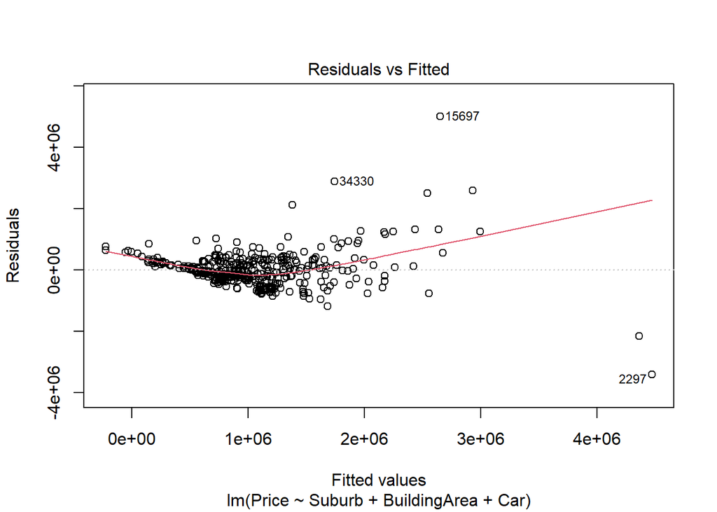

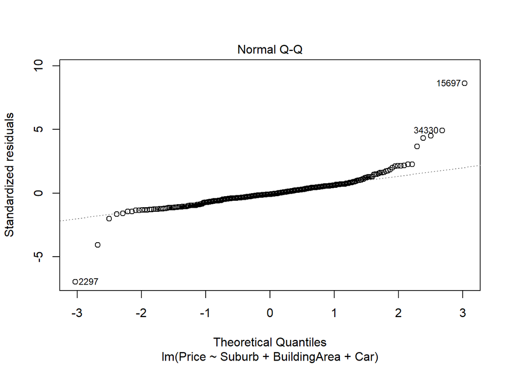

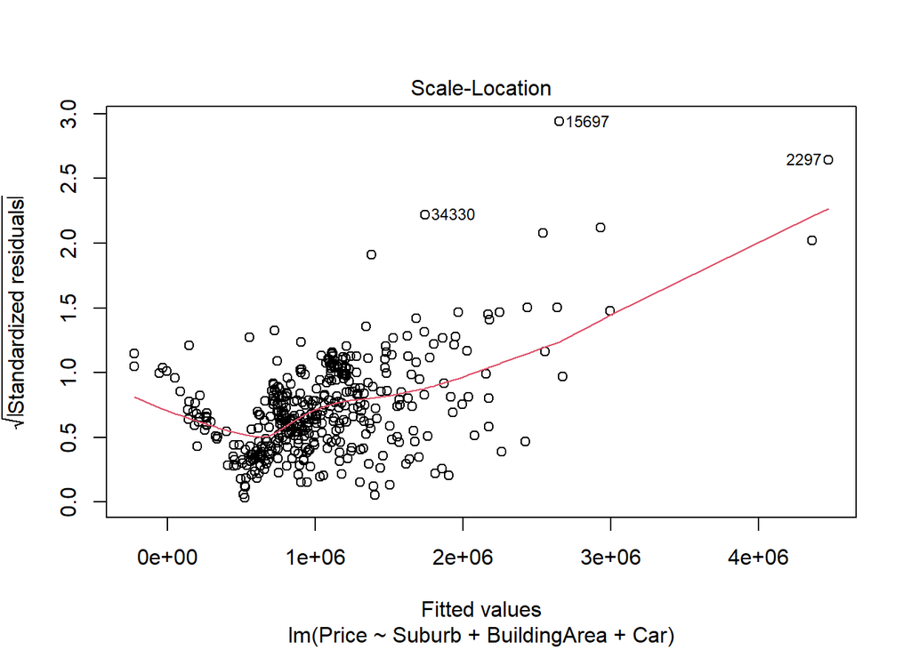

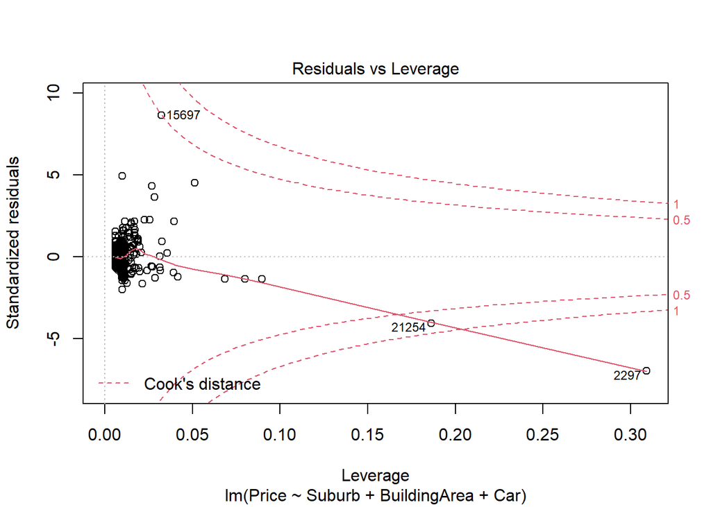

```r
plot(lmfit3)
```

```r
lmfit4 <- lm(Price ~ BuildingArea + Car, data = suburbs)
summary(lmfit4)
```

```
##
## Call:
## lm(formula = Price ~ BuildingArea + Car, data = suburbs)
##
## Residuals:
##      Min       1Q   Median       3Q      Max
## -3003810  -475084  -139874   273674  5816673
##
## Coefficients:
##              Estimate Std. Error t value Pr(>|t|)
## (Intercept)  406906.8    77684.5   5.238 2.62e-07 ***
## BuildingArea   3395.2      434.8   7.808 5.04e-14 ***
## Car          115549.2    41525.2   2.783  0.00564 **
## ---
## Signif. codes:  0 '***' 0.001 '**' 0.01 '*' 0.05 '.' 0.1 ' ' 1
##
## Residual standard error: 731300 on 404 degrees of freedom
##   (720 observations deleted due to missingness)
## Multiple R-squared:  0.1883, Adjusted R-squared:  0.1843
## F-statistic: 46.85 on 2 and 404 DF,  p-value: < 2.2e-16
```

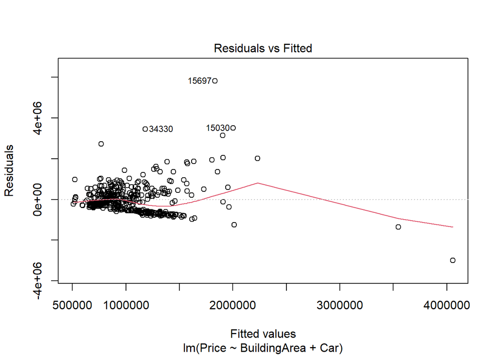

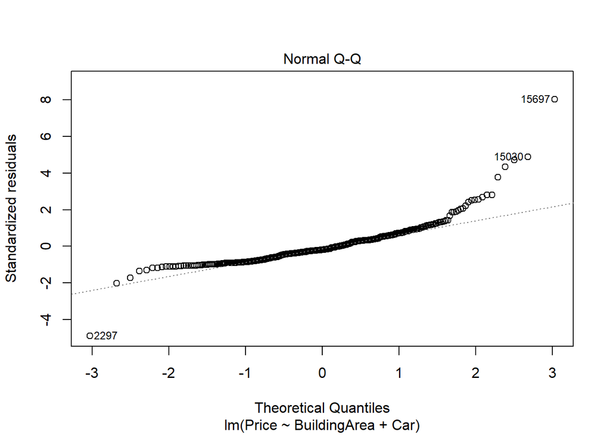

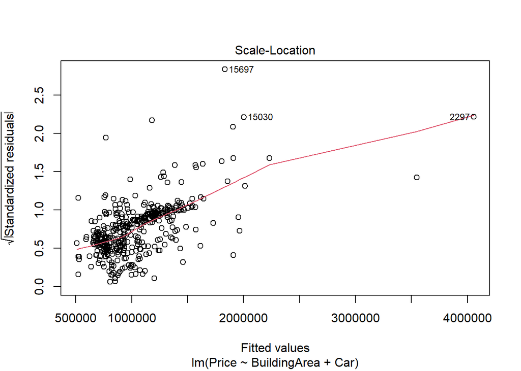

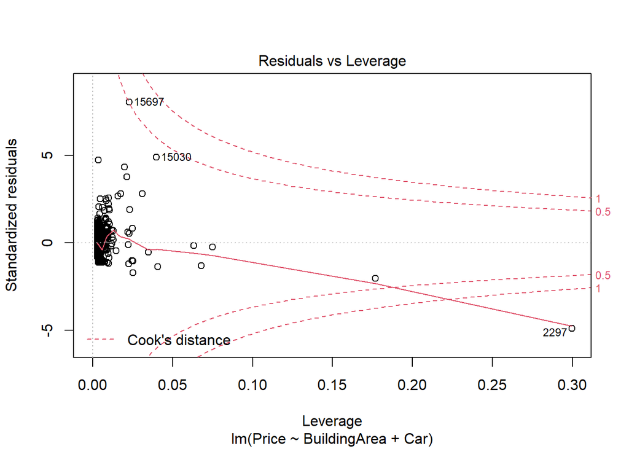

```r
plot(lmfit4)
```

As can be seen, the R squared for a model combining cuburb, area and number of cars as the predictor gives a better fit of R squared 0.477. However, if we remove suburb from the model we get a poor R squared value of 0.1883 which indicates that the bigger influencer on the price is the suburb.